# Final_RMD

Matthew Brown

December 15, 2018

## Background

Car crashes in the United States results in over 30,000 fatalities annually. Kaggle.com hosts a dataset on every car related fatality for 2015. It is titled US Traffic Fatality Records. It contains many interesting features such as the light condition, if there was a drunk driver involved in the crash, and the atmospheric condition. Often times we have stereo types of what conditions lead to the safest driving experience. We often believe that poor atmospheric conditions, lighting, population of an area, and number of drunk drivers all contribute significantly to the number of car related fatalities. This analysis will focus only on one of these attributes. Specifically, it will focus on how the population of an area effects the fatality rate of an area.The question this analysis will answer is “Is the population of a county the major factor in the fatality rate per 100,000 people in Idaho?”

## Population Analysis

To analyze the effect of population on car fatalities in Idaho, we will examine the following graphics.

First we will look at a graphic that shows the spread of population for each county in Idaho. Then we will look at how many fatalities are in each county. The next graphic shows the fatality rate of each county. The previous graphics will then help to describe what is happening in the final graphic. The final graphic shows the geographical location of every car fatality in Idaho. Each county is labeled and colored based on it’s population density.

### County Populations

Most of the population in Idaho is located in the following counties:  
Ada, Canyon, Kootenai, Bonneville, Bannock, and Twin Falls. As such we would expect to see the most fatalities occuring in those counties.

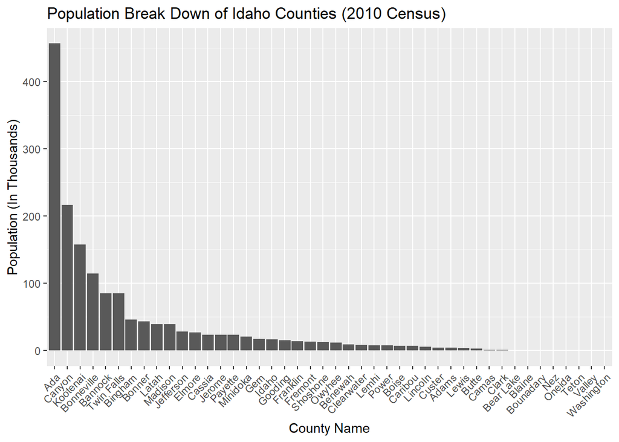

### Fatalities By County

The counties with the most fatalites are Canyon, Ada, Bingham, Bonner, Kootenai, and Twin Falls. Interestingly enough, Ada county had 2 less fatalities then Canyon even though Ada nearly doubles the population of Canyon county. In addition, Bannock county nearly doubles the population size of Bonner county, and yet Bannock county has 2/3rds the fatalities as Bonner County. The last oddity is that Bonneville, Madison county, Gem county, and Latah county are above the median county population in Idaho, and yet they are on the lower ends of total fatalities. If population was the decisive factor in the number of fatalities in an area, we would expect to see these counties on the left side of the graphic.

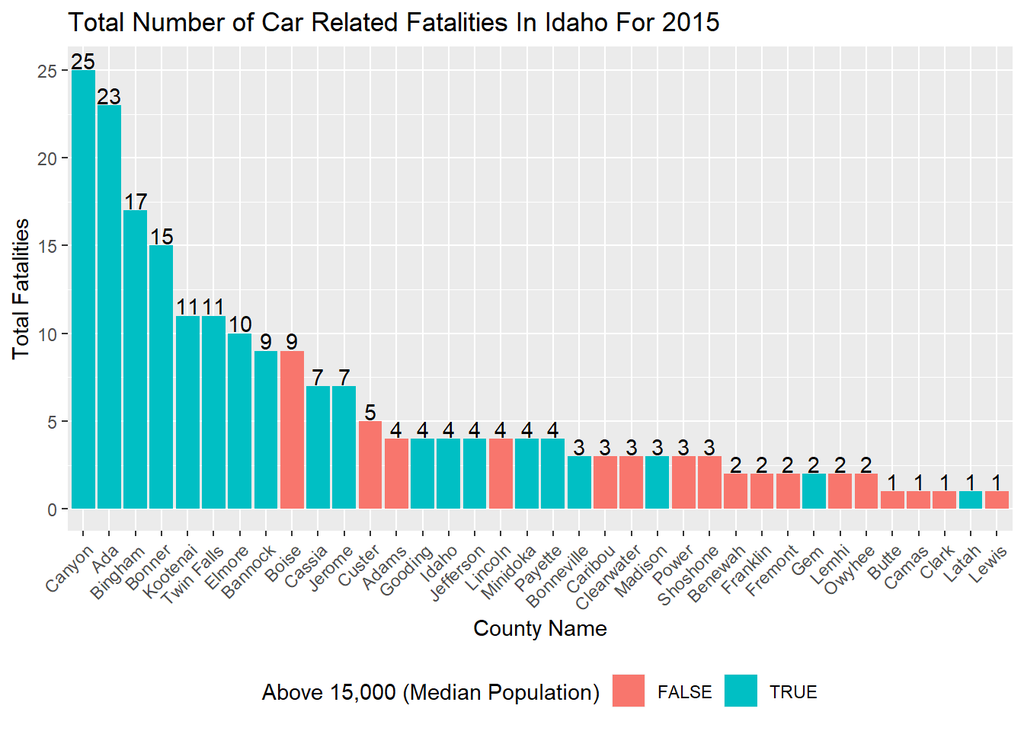

## Fatality Rates Per 100,000 Peoples

The graphic below shows the fatality rate per 100,000 peoples in each county. This number came from the following equation:

$Fatality Rate =$ $100,000 \times NumberFatalities\over CountyPopulation$

What is interesting about this graphic is that the counties with a lower population tend to be higher on the fatality rate. If population was the sole dependent variable contributing to the the fatality rates of a county, we would expect to see Ada county with the highest fatality rate. However, it only has a fatality rate of 5, where as Canyon County, the second largest county, has a rate of 11.

This implies that there is another factor influencing the rate of fatalities in an area. One such factor could be that the number of travelers n an area is not completely dependent on the number of people living in a county. This is something that one might assume, because travellers cross multiple counties to get to their destinations.

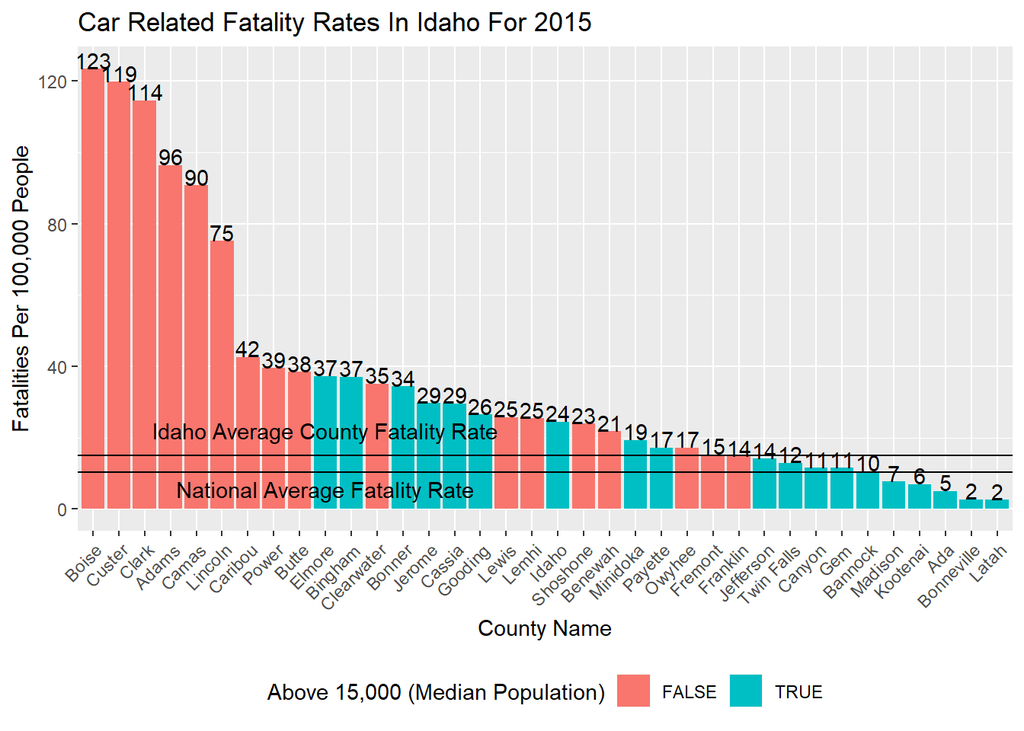

## Fatal Crashes by Geo Location

The graphic below shows the location of every car crash in Idaho for 2015. Fatal car crashes tend to follow major highways and interstates.

[interactive chart not shown]

## Building The Dataset

The “Master Dataset”, so to speak, contained five datasets that were merged together. Below, I describe each in detail.

#### US Fatalaties

Location: https://www.kaggle.com/usdot/nhtsa-traffic-fatalities  
To build this dataset, I had to use Python to interface with Google’s Big Query. I selected the features below:

state_name  
county  
city  
hour_of_crash  
day_of_crash  
month_of_crash  
light_condition_name  
atmospheric_conditions_1_name  
number_of_fatalities  
number_of_drunk_drivers  
timestamp_of_crash  
latitude  
longitude

The description for each feature can be found at the following link https://www.kaggle.com/usdot/nhtsa-traffic-fatalities.

This dataset needed to be cleaned. The biggest problem I had was that the counties feature did not have the actual name of the county. Instead, it had a government issued geo location code. In order to replace this code with a county name, I had to research what this code was. I then discovered a government-built dataset containing the names for each code. This is the National Fed Codes dataset discussed below.

#### National Fed Codes

Location: https://www.gsa.gov/reference/geographic-locator-codes-glcs-overview

This dataset contains the national geo location codes for each county in the United States. It’s usefull if one wants to convert these codes into actual county names.

#### US County Geometries

Location: USAboundaries R package  
I wanted to be able to display each county on my leaflet map. To do this, I merged the USAboundaries dataset with my accident dataset.

#### US Idaho County Populations

Location: https://www.idaho-demographics.com/counties_by_population the USAboundaries datasets did not give me an accurate county population count. I had to find data on the populations of each county in Idaho. The above link has this data. I then used it to build a dataset containing the populations of each Idaho County.